# individual_2

Cody Nielsen

11/8/2020

## Load data & libraries

```r
library(ggplot2)
library(tidyverse)
library(readxl)
```

```r
acc <- read.csv("https://raw.githubusercontent.com/xdaiISU/ds202materials/master/hwlabs/fars2017/accident.csv", stringsAsFactors = FALSE)

person <- read.csv("https://raw.githubusercontent.com/xdaiISU/ds202materials/master/hwlabs/fars2017/person.csv", stringsAsFactors = FALSE)
```

## Questions

1. Are there some days of the week where more accidents happen than the others (see FARS manual, use variable DAY_WEEK)?

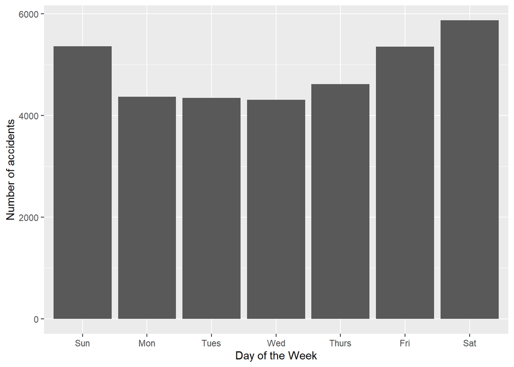

```r
ggplot(acc, aes(x=factor(DAY_WEEK, label=c('Sun', 'Mon', 'Tues','Wed', 'Thurs','Fri', 'Sat')))) + geom_bar() + xlab('Day of the Week') + ylab('Number of accidents')
```

It looks like accidents increase as the week progresses starting from Thursday and the highest number of accidents is on Saturday.

2.Create a data frame containing the persons who are fatally hurt in the accidents (look up variable INJ_SEV)

```r
fatal_hurt <- person %>%filter(INJ_SEV == 4)

head(fatal_hurt)
```

```
##   STATE ST_CASE VE_FORMS VEH_NO PER_NO STR_VEH COUNTY DAY MONTH HOUR MINUTE
## 1     1   10001        1      1      1       0     73  19     2   23     35
## 2     1   10002        1      1      1       0     89  14     2   14     59
## 3     1   10003        3      2      1       0    101  31     1   20     31
## 4     1   10004        1      1      1       0     73   1     1   16     55
## 5     1   10005        1      1      1       0     13   1     1   20      0
## 6     1   10006        2      1      1       0     49   6     1   18     40
##   RUR_URB FUNC_SYS HARM_EV MAN_COLL SCH_BUS MAKE MAK_MOD BODY_TYP MOD_YEAR
## 1       2        1      38        0       0   20   20421       15     2004
## 2       2        1       1        0       0   37   37402       14     2005
## 3       2        1      12        1       0    2    2404       14     2003
## 4       2        4      30        0       0   30   30046        4     2014
## 5       1        1      35        0       0   12   12471       34     2010
## 6       1        1      34        0       0   49   49032        4     1997
##   TOW_VEH SPEC_USE EMER_USE ROLLOVER IMPACT1 FIRE_EXP AGE SEX PER_TYP INJ_SEV
```

[output cut: 41 more lines]

3. Create a data frame containing the most dangerous vehicle make in each state. The number of persons fatally hit in the vehicle make is used to assess the (non-)safety of a make. Make sure to handle the missing values appropriately. (look up variable MAKE)

```r
danger_vehicles <- fatal_hurt %>% group_by(MAKE, INJ_SEV,na.rm = TRUE) %>% arrange(MAKE, INJ_SEV)

fatal_hurt %>% group_by(STATE, MAKE) %>% summarize(n = n()) %>% group_by(STATE) %>% filter(n == max(n))
```

```
## # A tibble: 54 x 3
## # Groups:   STATE [51]
##    STATE  MAKE     n
##    <int> <int> <int>
##  1     1    12   138
##  2     2    NA    17
##  3     4    NA   261
##  4     5    20    88
##  5     6    NA  1012
##  6     8    NA   108
##  7     9    NA    51
##  8    10    NA    39
##  9    11    NA    13
## 10    12    NA   803
## # ... with 44 more rows
```

```r
head(danger_vehicles)
```

```
## # A tibble: 6 x 69
## # Groups:   MAKE, INJ_SEV, na.rm [1]
##   STATE ST_CASE VE_FORMS VEH_NO PER_NO STR_VEH COUNTY   DAY MONTH  HOUR MINUTE
##   <int>   <int>    <int>  <int>  <int>   <int>  <int> <int> <int> <int>  <int>
## 1     1   10003        3      2      1       0    101    31     1    20     31
## 2     1   10016        1      1      1       0    121     4     1    17     10
## 3     1   10110        1      1      1       0     95     9     3    22     25
## 4     1   10193        1      1      1       0    125     5     5     1     15
## 5     1   10194        1      1      1       0     39     7     5     2      0
## 6     1   10210        4      1      1       0     45     7     4    11      0
## # ... with 58 more variables: RUR_URB <int>, FUNC_SYS <int>, HARM_EV <int>,
## #   MAN_COLL <int>, SCH_BUS <int>, MAKE <int>, MAK_MOD <int>, BODY_TYP <int>,
## #   MOD_YEAR <int>, TOW_VEH <int>, SPEC_USE <int>, EMER_USE <int>,
## #   ROLLOVER <int>, IMPACT1 <int>, FIRE_EXP <int>, AGE <int>, SEX <int>,
## #   PER_TYP <int>, INJ_SEV <int>, SEAT_POS <int>, REST_USE <int>,
## #   REST_MIS <int>, AIR_BAG <int>, EJECTION <int>, EJ_PATH <int>,
## #   EXTRICAT <int>, DRINKING <int>, ALC_DET <int>, ALC_STATUS <int>,
## #   ATST_TYP <int>, ALC_RES <int>, DRUGS <int>, DRUG_DET <int>, DSTATUS <int>,
## #   DRUGTST1 <int>, DRUGTST2 <int>, DRUGTST3 <int>, DRUGRES1 <int>,
## #   DRUGRES2 <int>, DRUGRES3 <int>, HOSPITAL <int>, DOA <int>, DEATH_DA <int>,
## #   DEATH_MO <int>, DEATH_YR <int>, DEATH_HR <int>, DEATH_MN <int>,
## #   DEATH_TM <int>, LAG_HRS <int>, LAG_MINS <int>, P_SF1 <int>, P_SF2 <int>,
## #   P_SF3 <int>, WORK_INJ <int>, HISPANIC <int>, RACE <int>, LOCATION <int>,
## #   na.rm <lgl>
```

4. Create a map, and label each state with the most dangerous vehicle. Discuss the definition of the most dangerous vehicle, and what you find from the map. (Hint: Read the description for the STATE and COUNTY columns in the FARS manual. The state & county codes are Geographic Locator Codes (GLCs) from the General Services Administration’s (GSA) publication. Use readxl::read_xlsx to read in the GLCs.)

```r
glcs <- read_xlsx("FRPP_GLC_-_United_StatesSep292020.xlsx")
```

```r
states = map_data('state')
glcs$'State Code' <- as.numeric(glcs$'State Code')
glcs$'County Code' <-as.numeric(glcs$'County Code')
fatal_hurt$MAKE = as.factor(fatal_hurt$MAKE)



# danger_map <- fatal_hurt %>% left_join(glcs %>% select(c('State Name', 'State Code')), by = c('STATE' = 'State Code')) %>% mutate('State Name' = tolower('State Name')) %>% unique() %>%
#   left_join(counties, by = c('State Name' = 'subregion'))
#
# ggplot(states, aes(x = long, y = lat)) +
#   geom_polygon(aes(group = group)) +
#   geom_polygon(data = danger_map,
#                aes(x = long, y = lat, group = group, fill = MAKE)) +
#   coord_map()
```

5. Join the accident and person table (work out which variable(s) to use)

```r
acci_person <- inner_join(acc, person)
head(acci_person)
```

```
##   STATE ST_CASE VE_TOTAL VE_FORMS PVH_INVL PEDS PERNOTMVIT PERMVIT PERSONS
## 1     1   10001        1        1        0    0          0       1       1
## 2     1   10002        1        1        0    0          0       1       1
## 3     1   10003        3        3        0    0          0       3       3
## 4     1   10003        3        3        0    0          0       3       3
## 5     1   10003        3        3        0    0          0       3       3
## 6     1   10004        1        1        0    0          0       1       1
##   COUNTY CITY DAY MONTH YEAR DAY_WEEK HOUR MINUTE NHS RUR_URB FUNC_SYS RD_OWNER
## 1     73  330  19     2 2017        1   23     35   1       2        1        1
## 2     89 1730  14     2 2017        3   14     59   1       2        1        1
## 3    101 2130  31     1 2017        3   20     31   1       2        1        1
## 4    101 2130  31     1 2017        3   20     31   1       2        1        1
## 5    101 2130  31     1 2017        3   20     31   1       2        1        1
## 6     73  350   1     1 2017        1   16     55   0       2        4        4
##   ROUTE        TWAY_ID       TWAY_ID2 MILEPT LATITUDE  LONGITUD SP_JUR HARM_EV
```

[output cut: 69 more lines]

6. Tally the number of accidents by day of the week (DAY_WEEK), hour of the day (HOUR) and gender (SEX). Visualize the results.

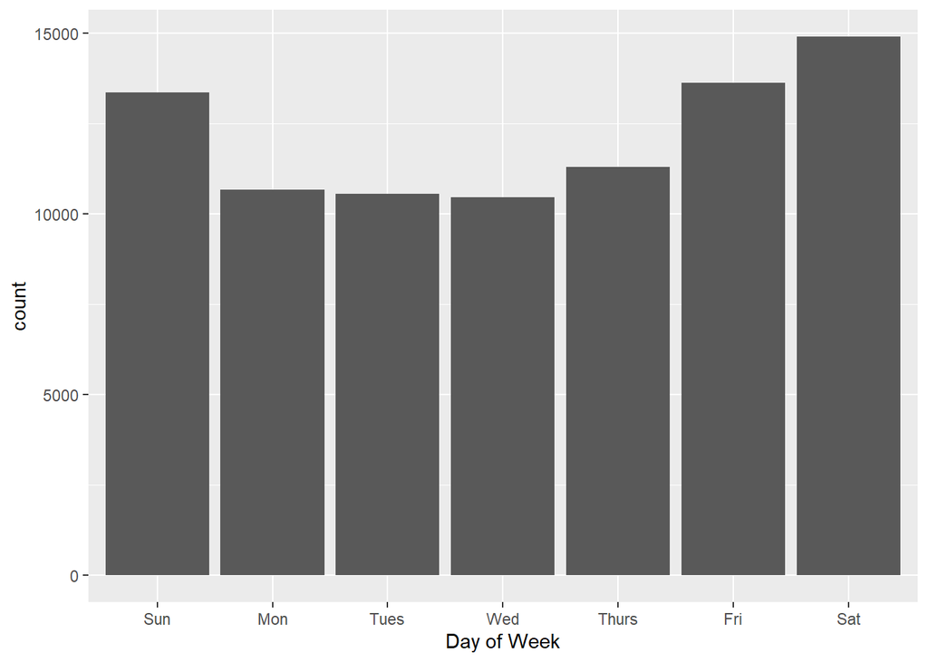

```r
acci_person %>% select(-c(HOUR)) %>% group_by(DAY_WEEK) %>% summarise(count = n()) %>% ggplot(aes(x=factor(DAY_WEEK, label=c('Sun', 'Mon', 'Tues','Wed', 'Thurs','Fri', 'Sat')))) + geom_bar(aes(weight=count)) + xlab("Day of Week")
```

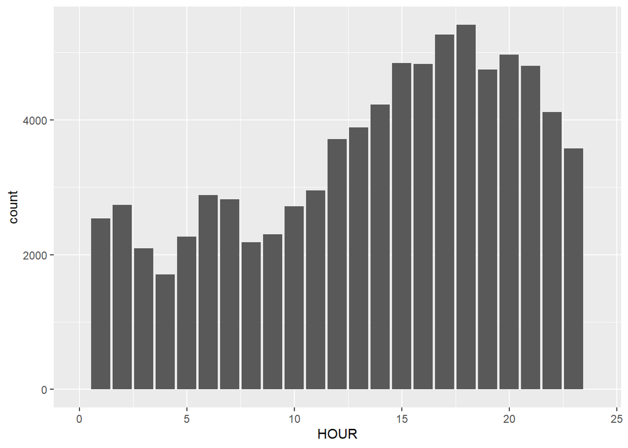

```r
acci_person %>% select(-c(HOUR)) %>% left_join(acc, by="ST_CASE") %>% group_by(HOUR) %>% summarise(count = n()) %>% ggplot(aes(x=HOUR)) + geom_bar(aes(weight=count))+xlim(0,24)
```

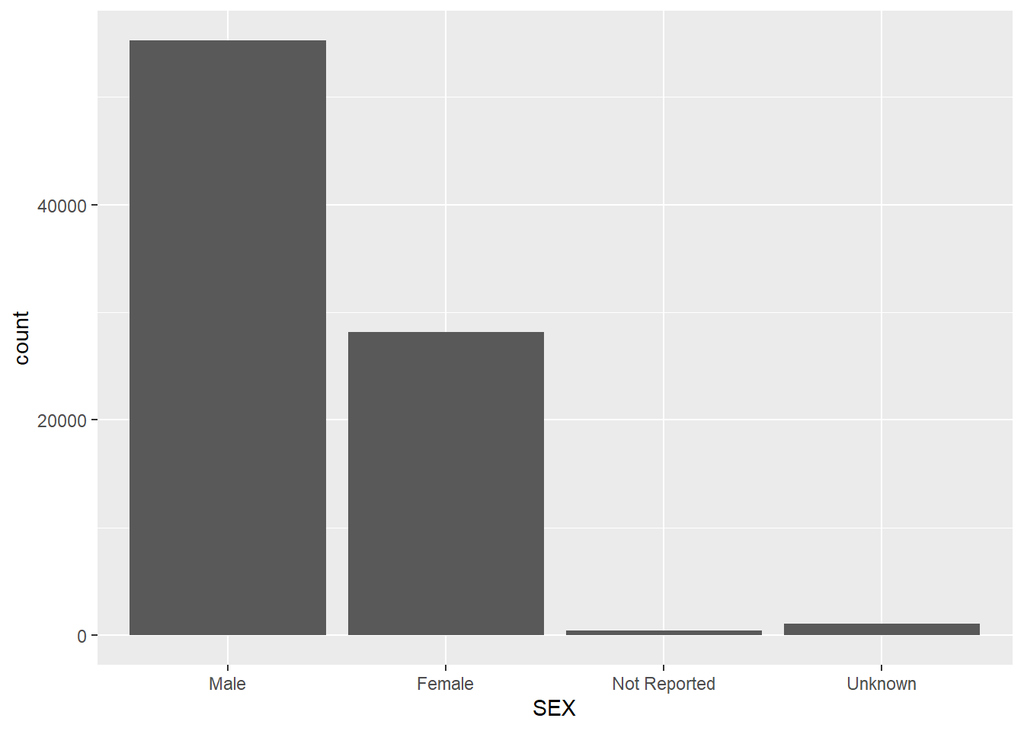

```r
acci_person$SEX <- factor(acci_person$SEX)
acci_person %>% select(-c(HOUR)) %>% left_join(acc, by="ST_CASE") %>% group_by(SEX) %>% summarise(count = n()) %>% ggplot(aes(x=factor(SEX, label=c('Male', 'Female', 'Not Reported', 'Unknown')))) + geom_bar(aes(weight=count)) + xlab('SEX')
```

7. Now plot a choropleth map of the number of deaths on a county level.

[figure not shown]

```r
counties <- map_data('county')

deaths <- acc %>% group_by(COUNTY) %>% summarise(death_sum = sum(FATALS), .groups = 'drop')

death_map <- deaths %>% left_join(glcs %>% select(c('County Name', 'County Code')), by = c('COUNTY' = 'County Code'))  %>% unique() %>% left_join(counties, by = c('County Name' = 'subregion'))

ggplot(counties, aes(x = long, y = lat)) + geom_polygon(aes(group = group)) +
  geom_polygon(data = death_map, aes(x = long, y = lat, group = group, fill = death_sum)) + coord_map()
```

8. Is summer or winter more dangerous? Does this depend on states? Explore and explain.

```r
winter <- acc %>%  filter(MONTH %in% c(6, 7, 8)) %>%
  group_by(STATE)

summer <- acc %>%  filter(MONTH %in% c(12, 1, 2)) %>%
  group_by(STATE)

dat1 <-winter %>% summarize(total =nrow(winter))
dat1$season = 'winter'
dat2 <- summer %>% summarize(total =nrow(summer))
```

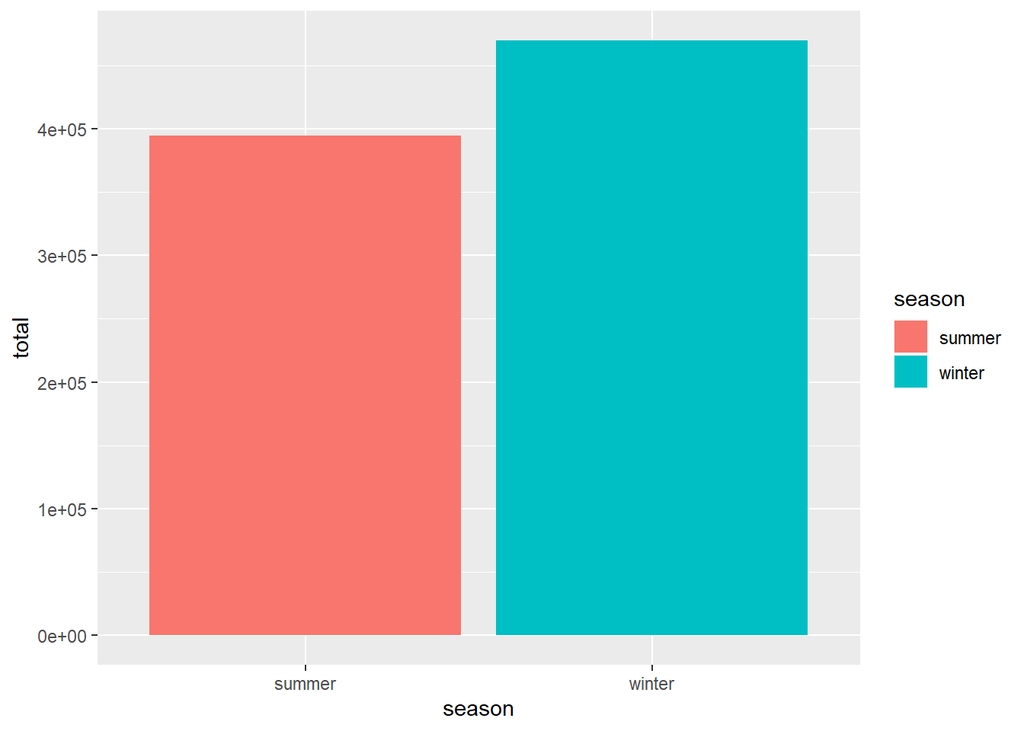

```r
dat2$season = 'summer'
season <- merge(dat1,dat2,all=TRUE)

ggplot(season ,aes(x= season, y =total,fill =season)) +geom_bar(stat='identity')
```